# FigureYa151pathifier

**Author(s)**: Xiaofan Lu  
**Reviewer(s)**: Ying Ge, Junyi Shen  
**Date**: `r Sys.Date()`

# Academic Citation

If you use this code in your work or research, we kindly request that you cite our publication:

Xiaofan Lu, et al. (2025). FigureYa: A Standardized Visualization Framework for Enhancing Biomedical Data Interpretation and Research Efficiency. iMetaMed. https://doi.org/10.1002/imm3.70005

# 需求描述

# Requirement

使用R package “pathifier”，根据样本基因表达水平，计算指定基因通路得分，并绘制热图。 Use the R package “pathifier” to calculate the pathway score of a specified gene based on the gene expression levels of the sample and draw a heatmap.

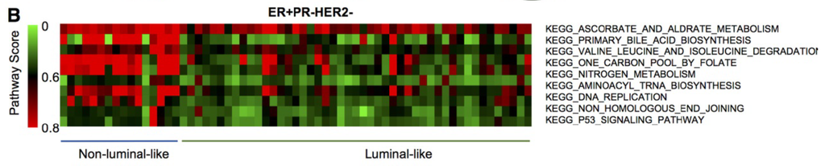

出自https://www.thno.org/v08p6386.htm From https://www.thno.org/v08p6386.htm

Figure 4. Identification of “non-luminal-like” subgroup from ER+PR-HER2- breast cancer. (B) Enriched pathways in the Kyoto Encyclopedia of Genes and Genomes (KEGG) collection of the non-luminal-like subgroup compared to the luminal-like subgroup of the TCGA cohort by **Pathifier algorithm**. Heatmap showing the pathway scores of each ER+PR-HER2- tumor.

The non-luminal-like subtype in the ER+PR-HER2- group presented **higher Pathifier [29] scores in** biosynthesis, metabolism and DNA replication (Figure 4B) and lower endocrine sensitivity scores (P<0.05, Figure 4C and Figure S7A).

# 应用场景

# Application Scenarios

用差异基因列表做富集分析，或做GSEA，有时会因为参数设置原因而看不到自己感兴趣的通路，这时可以把基因的表达矩阵转换为通路的表达矩阵，就可以直接观察自己感兴趣的通路的表达矩阵了。 When performing enrichment analysis or GSEA using a differentially expressed gene list, pathways of interest may not be visible due to parameter settings. In such cases, converting the gene expression matrix to a pathway expression matrix allows direct visualization of the pathway of interest.

另外，R包GSVA也能够实现类似的功能，用法可参考FigureYa61GSVA。 Alternatively, the R package GSVA can also perform similar functions. For usage, see FigureYa61GSVA.

# 环境设置

# Environment Setup

Using a Chinese mirror to install the package

```r
source("install_dependencies.R")
```

```
## Starting R package installation...
## ===========================================
##
## Installing CRAN packages...
## Package already installed: data.table
## Package already installed: gplots
## Package already installed: pheatmap
## Package already installed: devtools
##
## Installing Bioconductor packages...
## Package already installed: pathifier
##
## ===========================================
## Package installation completed!
## You can now run your R scripts in this directory.
```

```r
BiocManager::install("pathifier")
```

Loading the package

```r
library(pathifier)
library(data.table)
library(pheatmap)
library(gplots)
Sys.setenv(LANGUAGE = "en") #显示英文报错信息 #Display English error messages
options(stringsAsFactors = FALSE) #禁止chr转成factor #Disable conversion of chr to factor
```

自定义函数（来自cogena） Custom function (from cogena)

```r
# 读取gmt文件为列表形式，满足pathifier的输入要求
# Read the gmt file as a list to meet the pathifier input requirements
gmt2list <- function(annofile){
  if (!file.exists(annofile)) {
    stop("There is no such gmt file.")
  }

  if (tools::file_ext(annofile) == "xz") {
    annofile <- xzfile(annofile)
    x <- scan(annofile, what="", sep="\n", quiet=TRUE)
    close(annofile)
  } else if (tools::file_ext(annofile) == "gmt") {
    x <- scan(annofile, what="", sep="\n", quiet=TRUE)
  } else {
    stop ("Only gmt and gmt.xz are accepted for gmt2list")
  }

  y <- strsplit(x, "\t")
  names(y) <- sapply(y, `[[`, 1)

  annoList <- lapply(y, `[`, c(-1,-2))
}
```

# 感兴趣的通路genelist

# Genelist of pathways of interest

运行pathifier时，gmt文件里的通路/基因越多，时间越长。 When running pathifier, the more pathways/genes in the gmt file, the longer it takes.

怎样获得感兴趣的通路的gmt文件？ How can I obtain the gmt file for the pathway of interest?

- 方法一：从GSEA网站下载gmt文件http://software.broadinstitute.org/gsea/downloads.jsp，可以直接用（运行时间长）；
- 方法二：从方法一获得的gmt文件里提取感兴趣的通路；
- 方法三：用已发表的文章里的差异基因，思路可参考这篇：https://mp.weixin.qq.com/s/O1xd5l5h33fXUWOvX3UBGw“如果我真的对其中某一个概念和Term很感兴趣与执着的话，我会重新找到发表相关功能或者通路的文章，重新构建Term的genelist。”类似的思路可参考FigureYa136fgsea。
- Method 1: Download the gmt file from the GSEA website http://software.broadinstitute.org/gsea/downloads.jsp and use it directly (this process may take a long time).
- Method 2: Extract the pathway of interest from the gmt file obtained in Method 1.
- Method 3: Use differentially expressed genes from published articles. For ideas, refer to this article: https://mp.weixin.qq.com/s/O1xd5l5h33fXUWOvX3UBGw: “If I’m truly interested in and obsessed with a concept or term, I’ll find articles that publish related functions or pathways and rebuild the term’s genelist.” For similar ideas, refer to Figure Ya136fgsea.

## 方法一：直接用下载的gmt文件

## Method 1: Use the downloaded gmt file directly

```r
gset <- gmt2list("customized.gmt")
gset[1]
```

```
## $KEGG_ASCORBATE_AND_ALDARATE_METABOLISM
##  [1] "ALDH1B1" "ALDH2"   "ALDH3A2" "ALDH7A1" "ALDH9A1" "MIOX"    "UGDH"
##  [8] "UGT1A1"  "UGT1A10" "UGT1A3"  "UGT1A4"  "UGT1A5"  "UGT1A6"  "UGT1A7"
## [15] "UGT1A8"  "UGT1A9"  "UGT2A1"  "UGT2A3"  "UGT2B10" "UGT2B11" "UGT2B15"
## [22] "UGT2B17" "UGT2B28" "UGT2B4"  "UGT2B7"
```

后面将以customized.gmt为例来展示分析和画图方法，也就是gset。 The following will use customized.gmt as an example to demonstrate the analysis and drawing methods, that is, gset.

## 方法二：从gmt文件提取感兴趣的通路

## Method 2: Extract pathways of interest from a gmt file

```r
# 例如提取带有`METABOLISM`字样的通路 # For example, extract pathways with the word `METABOLISM`
gset_meta <- gset[names(gset) %like% "METABOLISM"]
gset_meta
```

```
## $KEGG_ASCORBATE_AND_ALDARATE_METABOLISM
##  [1] "ALDH1B1" "ALDH2"   "ALDH3A2" "ALDH7A1" "ALDH9A1" "MIOX"    "UGDH"
##  [8] "UGT1A1"  "UGT1A10" "UGT1A3"  "UGT1A4"  "UGT1A5"  "UGT1A6"  "UGT1A7"
## [15] "UGT1A8"  "UGT1A9"  "UGT2A1"  "UGT2A3"  "UGT2B10" "UGT2B11" "UGT2B15"
## [22] "UGT2B17" "UGT2B28" "UGT2B4"  "UGT2B7"
##
## $KEGG_NITROGEN_METABOLISM
##  [1] "AMT"   "ASNS"  "CA1"   "CA12"  "CA13"  "CA14"  "CA2"   "CA3"   "CA4"
## [10] "CA5A"  "CA5B"  "CA6"   "CA7"   "CA8"   "CA9"   "CPS1"  "CTH"   "GLS"
## [19] "GLS2"  "GLUD1" "GLUD2" "GLUL"  "HAL"
```

```r
#gset <- gset_meta
```

## 方法三：用文章里的基因

## Method 3: Use genes from the paper

把感兴趣的基因名保存到文本文件里，每行一个基因，共一列，命名为`gene_paper*.txt` Save the gene names of interest to a text file, one gene per line, one column, named `gene_paper*.txt`

```r
read.aschar <- function(filename){
  file <- read.table(filename)
  file <- file$V1
}

fnames <- list.files(pattern = "gene_paper")
fnames
```

```
## [1] "gene_paper1.txt" "gene_paper2.txt" "gene_paper3.txt"
```

```r
gset_paper <- lapply(fnames, read.aschar)
# 用文件名作为通路的名字 # Use the file name as the pathway name
names(gset_paper) <- fnames
gset_paper
```

```
## $gene_paper1.txt
##  [1] "ALDH1B1" "ALDH2"   "ALDH3A2" "ALDH7A1" "ALDH9A1" "MIOX"    "UGDH"
##  [8] "UGT1A1"  "UGT1A10" "UGT1A3"  "UGT1A4"  "UGT1A5"  "UGT1A6"  "UGT1A7"
## [15] "UGT1A8"  "UGT1A9"  "UGT2A1"  "UGT2A3"  "UGT2B10" "UGT2B11" "UGT2B15"
## [22] "UGT2B17" "UGT2B28" "UGT2B4"  "UGT2B7"
##
## $gene_paper2.txt
##  [1] "ACOX2"   "AKR1C4"  "AKR1D1"  "AMACR"   "BAAT"    "CH25H"   "CYP27A1"
##  [8] "CYP39A1" "CYP46A1" "CYP7A1"  "CYP7B1"  "CYP8B1"  "HSD17B4" "HSD3B7"
## [15] "SCP2"    "SLC27A5"
##
## $gene_paper3.txt
##  [1] "ABAT"     "ACAA1"    "ACAA2"    "ACAD8"    "ACADM"    "ACADS"
##  [7] "ACADSB"   "ACAT1"    "ACAT2"    "ALDH1B1"  "ALDH2"    "ALDH3A2"
## [13] "ALDH6A1"  "ALDH7A1"  "ALDH9A1"  "AOX1"     "AUH"      "BCAT1"
## [19] "BCAT2"    "BCKDHA"   "BCKDHB"   "DBT"      "DLD"      "ECHS1"
## [25] "EHHADH"   "HADH"     "HADHA"    "HADHB"    "HIBADH"   "HIBCH"
## [31] "HMGCL"    "HMGCS1"   "HMGCS2"   "HSD17B10" "IL4I1"    "IVD"
## [37] "MCCC1"    "MCCC2"    "MCEE"     "MMUT"     "OXCT1"    "OXCT2"
## [43] "PCCA"     "PCCB"
```

```r
# 或者自己另外起通路的名字 # Or, you can create your own pathway names.
names(gset_paper) <- c("author1_year1", "author2_year2", "author3_year3")
gset_paper
```

```
## $author1_year1
##  [1] "ALDH1B1" "ALDH2"   "ALDH3A2" "ALDH7A1" "ALDH9A1" "MIOX"    "UGDH"
##  [8] "UGT1A1"  "UGT1A10" "UGT1A3"  "UGT1A4"  "UGT1A5"  "UGT1A6"  "UGT1A7"
## [15] "UGT1A8"  "UGT1A9"  "UGT2A1"  "UGT2A3"  "UGT2B10" "UGT2B11" "UGT2B15"
## [22] "UGT2B17" "UGT2B28" "UGT2B4"  "UGT2B7"
##
## $author2_year2
##  [1] "ACOX2"   "AKR1C4"  "AKR1D1"  "AMACR"   "BAAT"    "CH25H"   "CYP27A1"
##  [8] "CYP39A1" "CYP46A1" "CYP7A1"  "CYP7B1"  "CYP8B1"  "HSD17B4" "HSD3B7"
## [15] "SCP2"    "SLC27A5"
##
## $author3_year3
##  [1] "ABAT"     "ACAA1"    "ACAA2"    "ACAD8"    "ACADM"    "ACADS"
##  [7] "ACADSB"   "ACAT1"    "ACAT2"    "ALDH1B1"  "ALDH2"    "ALDH3A2"
## [13] "ALDH6A1"  "ALDH7A1"  "ALDH9A1"  "AOX1"     "AUH"      "BCAT1"
## [19] "BCAT2"    "BCKDHA"   "BCKDHB"   "DBT"      "DLD"      "ECHS1"
## [25] "EHHADH"   "HADH"     "HADHA"    "HADHB"    "HIBADH"   "HIBCH"
## [31] "HMGCL"    "HMGCS1"   "HMGCS2"   "HSD17B10" "IL4I1"    "IVD"
## [37] "MCCC1"    "MCCC2"    "MCEE"     "MMUT"     "OXCT1"    "OXCT2"
## [43] "PCCA"     "PCCB"
```

```r
#gset <- gset_paper
```

# 输入文件

# Input files

easy_input_expr.txt，基因表达矩阵。 easy_input_expr.txt, gene expression matrix.

easy_input_info.txt，样本信息。 easy_input_info.txt, sample information.

```r
## 表达矩阵
## Expression matrix
expr <- read.table("easy_input_expr.txt",sep = "\t",check.names = F,stringsAsFactors = F,header = T,row.names = 1)
expr[1:3, 1:3]
```

```
##        BRCA-A06N-01A BRCA-A07S-01A BRCA-A084-01A
## TSPAN6         13.71         10.99          3.10
## TNMD            0.00          0.08          0.00
## DPM1           33.86         22.80         31.14
```

```r
# 移除低表达的基因
# Remove lowly expressed genes
expr <- expr[rowSums(expr) > 1,]

## 提取肿瘤和正常样本，用于计算pathway score
## Extract tumor and normal samples for pathway score calculation
sinfo <- read.table("easy_input_info.txt",sep = "\t",check.names = F,stringsAsFactors = F,header = T,row.names = 1)
head(sinfo)
```

```
##               er_status_by_ihc pr_status_by_ihc HER2.KH.FISH2.0
## BRCA-A3IZ-01A         Positive         Negative        Negative
## BRCA-A66N-01A         Positive         Negative        Negative
## BRCA-A13E-01A         Positive         Negative        Negative
## BRCA-A0J5-01A         Positive         Negative        Negative
## BRCA-A0SW-01A         Positive         Negative        Negative
## BRCA-A107-01A         Positive         Negative        Negative
##                          PAM50
## BRCA-A3IZ-01A     Luminal-like
## BRCA-A66N-01A     Luminal-like
## BRCA-A13E-01A Non-luminal-like
## BRCA-A0J5-01A     Luminal-like
## BRCA-A0SW-01A     Luminal-like
## BRCA-A107-01A     Luminal-like
```

```r
tum.sam <- intersect(colnames(expr)[grep("-01A",colnames(expr))],rownames(sinfo)) # 提取原发且符合要求的肿瘤（例文为ER+PR-HER2-） # Extract primary tumors that meet the requirements (in this example, ER+PR-HER2-).
nor.sam <- colnames(expr)[grep("-11A",colnames(expr))] # 提取癌旁组织 # Extract adjacent tissue

expr <- expr[,c(tum.sam,nor.sam)] # 重新排序 # Reorder
tissue.logic <- rep(c(F,T),c(length(tum.sam),length(nor.sam))) # 构建样本是否为正常的指示变量 # Construct an indicator variable for whether the sample is normal

## 按luminal-like和Non-luminal-like分为两组，画图时要用到该分组
## Divide into two groups based on luminal-like and non-luminal-like patterns. This grouping will be used when plotting.
# luminal-like samples
lum.sam <- intersect(rownames(sinfo[which(sinfo$PAM50 == "Luminal-like"),]),tum.sam)
# Non-luminal-like samples
nonlum.sam <- intersect(rownames(sinfo[which(sinfo$PAM50 == "Non-luminal-like"),]),tum.sam)
```

# 运行pathifier

# Run pathifier

用肿瘤和癌旁计算pathway score。 Calculate pathway scores using tumor and adjacent adjacent regions.

**注意：**这里用的是手动矫正过的gmt文件，如果用GSEA的通路（>1000），该算法运行速度会非常慢； **Note:** This uses a manually corrected gmt file. If using GSEA pathways (>1000), the algorithm will run very slowly.

粗略估计运行GSEA中的c5免疫相关通路可能需要10天以上。 A rough estimate is that running the c5 immune-related pathway in GSEA may take over 10 days.

```r
indata <- as.matrix(log2(expr + 1))
gname <- rownames(expr)
path.res <- quantify_pathways_deregulation(data = indata, # 表达谱，行为基因，列为样本(必须为矩阵) # Expression profiles, behavioral genes, listed as samples (must be a matrix)
                                           allgenes = gname, # 表达谱的基因名 # Gene names for the expression profiles
                                           syms = gset, # 感兴趣的通路列表 # List of pathways of interest
                                           pathwaynames = names(gset), # 通路列表的通路名  # Pathway names for the pathway list
                                           normals = tissue.logic, # 指示变量，如为癌旁则为TRUE # Indicator variable, TRUE if the value is adjacent to the cancer
                                           attempts = 100, # 运行次数，默认为100，提高次数可增加稳定性 # Number of runs, defaults to 100; increasing the number may improve stability
                                           min_exp = 0, # 默认值为4，倘若表达值低于该阈值，则填补该阈值 # Default is 4. If the expression value is below this threshold, the threshold is padded.
                                           min_std = 0) # 默认值位0.4，倘若某基因的标准差低于该阈值，则标准化时除以该阈值，而不使用真实标准差 # Default is 0.4. If the standard deviation of a gene is below this threshold, the normalization is divided by the threshold instead of the true standard deviation.
```

```
## robust_score_bydist. min_exp= 0 , min_std= 0
## pathway  1 > sig: 0.0186417
## pathway  2 > sig: 0.09781273
```

```
## pathway  2  k= 7 ( 7 ) wj= 1 >new sig: 0.05973727 | accepted!
## pathway  2  k= 6 ( 6 ) wj= 5 >new sig: 0.05376584 x rejected
## pathway  3 > sig: 0.03979935
## pathway  4 > sig: 0.02001812
## pathway  5 > sig: 0.05856174
## pathway  5  k= 11 ( 11 ) wj= 1 >new sig: 0.04330873 | accepted!
## pathway  6 > sig: 0.04097428
## pathway  7 > sig: 0.01734455
## pathway  8 > sig: 0.05957538
## pathway  9 > sig: 0.04423607
## 9 pathways processed with start= by ranks
```

```r
# 生成pathway score
# Generate pathway score
path.score <- as.data.frame(rbindlist(lapply(path.res$scores,as.data.frame))); dimnames(path.score) <- list(names(gset),colnames(expr))
# 保存到文件
# Save to file
write.csv(path.score, "pathifier_output.csv", quote = F)
```

下一步画出感兴趣的通路的热图； Next, plot a heatmap of the pathway of interest.

还可以算出所有通路的score，做差异表达分析，方法跟基因的差异表达分析类似，可参考FigureYa61GSVA。 You can also calculate the scores for all pathways and perform differential expression analysis. The method is similar to gene differential expression analysis, see Figure Ya61 GSVA.

# 开始画图

# Start plotting

这里复现原文里的画法，不聚类。 Here, we replicate the original method, without clustering.

更多聚类、排序的热图画法可参考FigureYa91cluster_heatmap。 For more clustering and ranking heatmap plotting techniques, see Figure Ya91 cluster_heatmap.

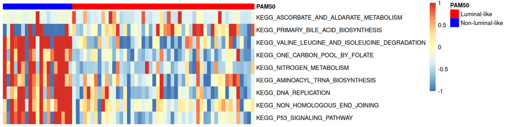

```r
# 这里在图中用颜色画出样本信息 Here, we use colors to plot sample information in the figure.
# 也可以像例文那样用illustrator打开pdf文件，添加横线 # You can also open the PDF file in Illustrator and add horizontal lines as in the example.
annCol <- data.frame(PAM50 = sinfo$PAM50,row.names = rownames(sinfo),stringsAsFactors = F)
annColors <- list("PAM50" = c("Luminal-like" = "red","Non-luminal-like" = "blue"))

# 热图数据标准化
# Normalize the heatmap data
plotdata <- t(scale(t(path.score[,c(nonlum.sam,lum.sam)])))
plotdata[plotdata > 1]  <- 1 # 数值大于1赋1 # Values greater than 1 are assigned a value of 1.
plotdata[plotdata < -1] <- -1 # 数值小于-1赋-1 # Values less than -1 are assigned a value of -1.

#pdf("pathifier.pdf",width = 15,height = 3)
pheatmap(plotdata,
         border_color = NA, #不画边框 #no border
         cluster_cols = F, cluster_rows = F, #不聚类  #no clustering
         #color = greenred(64), #原文的红绿配色 #original red and green color scheme
         annotation_col = annCol[c(nonlum.sam,lum.sam),,drop = F], #样本信息 #sample information
         annotation_colors = annColors, #样本信息配色 #sample information color scheme
         show_rownames = T, #显示通路名 #show pathway names
         show_colnames = F) #不显示样本名 #do not show sample names
```

```r
#dev.off()
#dev.off()
```

[figure not shown]